# Homework #4

#### Computing ID: cx2rx

**SYS 6018 | Fall 2020 | University of Virginia**

## Crime Linkage

Crime linkage attempts to determine if two or more unsolved crimes share a common offender. *Pairwise* crime linkage is the more simple task of deciding if two crimes share a common offender; it can be considered a binary classification problem. The linkage training data has 8 evidence variables that measure the similarity between a pair of crimes:

- `spatial` is the spatial distance between the crimes
- `temporal` is the fractional time (in days) between the crimes
- `tod` and `dow` are the differences in time of day and day of week between the crimes
- `LOC`, `POA,` and `MOA` are binary with a 1 corresponding to a match (type of property, point of entry, method of entry)
- `TIMERANGE` is the time between the earliest and latest possible times the crime could have occurred (because the victim was away from the house during the crime).
- The response variable indicates if the crimes are linked ($y=1$) or unlinked ($y=0$).

These problems use the [linkage-train](https://mdporter.github.io/SYS6018/data/linkage_train.csv) and [linkage-test](https://mdporter.github.io/SYS6018/data/linkage_test.csv) datasets (click on links for data).

### Problem 4.1: Penalized Regression for Crime Linkage

1. Fit a penalized *linear regression* model. Use a lasso, ridge, or elasticnet penalty (your choice).
   - Report the value of $\alpha$ used (if elasticnet)
   - Report the value of $\lambda$ used
   - Report the estimated coefficients

```r
# Read in training and testing data
train <- read_csv("https://mdporter.github.io/SYS6018/data/linkage_train.csv")
# test <- read_csv("https://mdporter.github.io/SYS6018/data/linkage_test.csv")

# Define Training data
X.train = train %>% select(-y) %>% as.matrix()
Y.train = train %>% select(y) %>% as.matrix()

# Control Randomness
set.seed(666)

# Cross Validation Setting
n.folds <- 10
fold <- sample(rep(1:n.folds, length = nrow(X.train)))

# Pre-defined setting
alpha <- seq(0, 1, 0.01)

# Create a empty list to store results
output <- list()

# Finding the best alpha
for (m in 1:length(alpha)) {

    # Build model using CV
    model <- cv.glmnet(x = X.train, y = Y.train, foldid = fold, alpha = alpha[m])

    # Store the data into output
    output[[m]] <- data.frame(alpha = alpha[m],
                              lambda = model$lambda.1se,
                              mse = model$cvm[which(model$lambda == model$lambda.1se)])

}

# Convert list back to data frame
output <- bind_rows(output)

# Report alpha and lambda for final prediction
best_linear <- output %>%
  filter(mse == min(mse))
print(best_linear)
```

```
#>   alpha     lambda        mse
#> 1  0.74 0.01639806 0.01576142
```

The parameters I will use for final model fitting are $\alpha = 0.74$, $\lambda = 0.01639806$. Estimated Coefficients are:

```r
# Report the estimated coefficients
best_linear_model <- cv.glmnet(x = X.train, y = Y.train, foldid = fold, alpha = best_linear$alpha)
coef(best_linear_model)
```

```
#> 9 x 1 sparse Matrix of class "dgCMatrix"
#>                         1
#> (Intercept)  4.167286e-02
#> spatial     -1.121034e-03
#> temporal    -4.997579e-05
#> tod          .
#> dow          .
#> LOC          1.242711e-02
#> POA          .
#> MOA          .
#> TIMERANGE    .
```

2. Fit a penalized *logistic regression* model. Use a lasso, ridge, or elasticnet penalty (your choice).
   - Report the value of $\alpha$ used (if elasticnet)
   - Report the value of $\lambda$ used
   - Report the estimated coefficients

```r
# Control Randomness
set.seed(666)

# Pre-defined setting
alpha <- seq(0, 1, 0.05)

# Create a empty list to store results
output <- list()

# Finding the best alpha
for (m in 1:length(alpha)) {

    # Build model using CV
    model <- cv.glmnet(x = X.train,
                       y = Y.train,
                       foldid = fold,
                       alpha = alpha[m],
                       family = 'binomial')

    # Store the data into output
    output[[m]] <- data.frame(alpha = alpha[m],
                              lambda = model$lambda.1se,
                              deviance = model$cvm[which(model$lambda == model$lambda.1se)])

}

# Convert list back to data frame
output <- bind_rows(output)

# Report alpha and lambda for final prediction
best_logit <- output %>%
  filter(deviance == min(deviance))
print(best_logit)
```

```
#>   alpha     lambda   deviance
#> 1   0.4 0.00224208 0.09563498
```

The parameters I will use for final model fitting are $\alpha = 0.4$, $\lambda = 0.00224208$. Estimated Coefficients are:

```r
# Report the estimated coefficients
best_logit_model <-
  cv.glmnet(
    x = X.train,
    y = Y.train,
    foldid = fold,
    alpha = min(best_logit$alpha),
    family = 'binomial'
  )
coef(best_logit_model)
```

```
#> 9 x 1 sparse Matrix of class "dgCMatrix"
#>                        1
#> (Intercept) -0.810993654
#> spatial     -0.185338322
#> temporal    -0.009790124
#> tod         -0.088318112
#> dow         -0.194351412
#> LOC          1.321120689
#> POA          0.336841782
#> MOA          0.124266004
#> TIMERANGE    0.000468719
```

3. Produce one plot that has the ROC curves, using the *training data*, for both models (from part a and b). Use color and/or linetype to distinguish between models and include a legend.

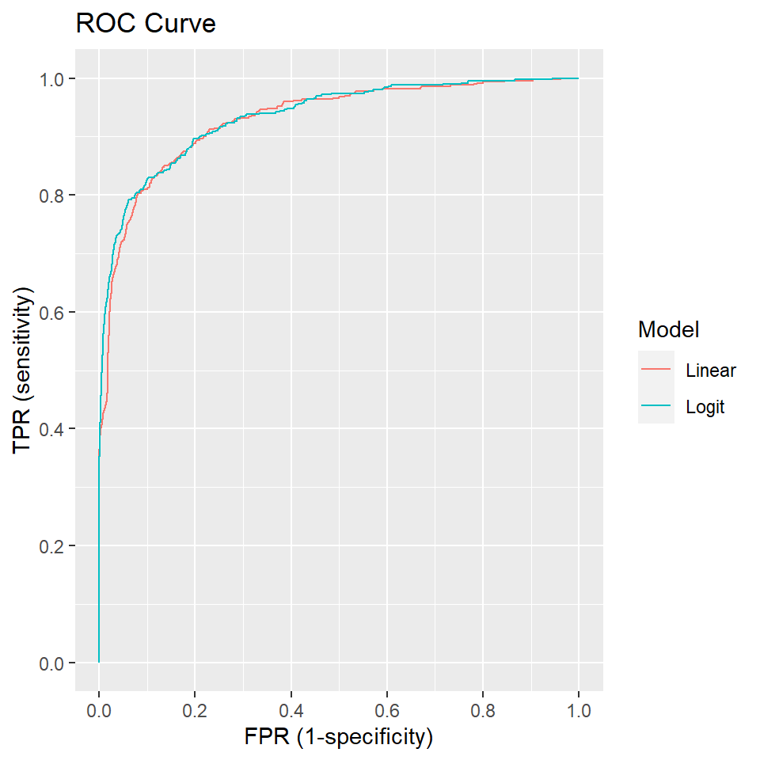

```r
# Set threshold
linear_roc <- train %>%
  select(y) %>%
  mutate(pred_linear = predict(best_linear_model, newx = X.train, type = "response")) %>%
  group_by(pred_linear) %>%
  summarize(n = n(),
            n.1 = sum(y),
            n.0 = n - sum(y)) %>%
  ungroup() %>%
  arrange(pred_linear) %>%
  mutate(FN = cumsum(n.1),    # false negatives
         TN = cumsum(n.0),    # true negatives
         TP = sum(n.1) - FN,  # true positives
         FP = sum(n.0) - TN,  # false positives
         N = cumsum(n),       # number of cases predicted to be 1
         TPR = TP/sum(n.1),
         FPR = FP/sum(n.0)) %>%
  #- only keep relevant metrics
  select(-n, -n.1, -n.0, pred_linear)

logit_roc <- train %>%
  select(y) %>%
  mutate(pred_logit = predict(best_logit_model, newx = X.train, type = "response")) %>%
  group_by(pred_logit) %>%
  summarize(n = n(),
            n.1 = sum(y),
            n.0 = n - sum(y)) %>%
  ungroup() %>%
  arrange(pred_logit) %>%
  mutate(FN = cumsum(n.1),    # false negatives
         TN = cumsum(n.0),    # true negatives
         TP = sum(n.1) - FN,  # true positives
         FP = sum(n.0) - TN,  # false positives
         N = cumsum(n),       # number of cases predicted to be 1
         TPR = TP/sum(n.1),
         FPR = FP/sum(n.0)) %>%
  #- only keep relevant metrics
  select(-n, -n.1, -n.0, pred_logit)

# Create a ROC Curve
ggplot() +
  geom_path(data = linear_roc, aes(x = FPR, y = TPR, color = "Linear")) +
  geom_path(data = logit_roc, aes(x = FPR, y = TPR, color = "Logit")) +
  scale_color_discrete(name = "Model") +
  labs(x = 'FPR (1-specificity)', y = 'TPR (sensitivity)') +
  geom_segment(x = 0, xend = 1, y = 0, yend = 1, lty = 3, color = 'grey50') +
  scale_x_continuous(breaks = seq(0, 1, by = .20)) +
  scale_y_continuous(breaks = seq(0, 1, by = .20)) +
  ggtitle("ROC Curve")
```

4. Recreate the ROC curve from the penalized logistic regression model using repeated hold-out data. The following steps will guide you:
   - Fix $\alpha=.75$
   - Run the following steps 25 times:
     1. Hold out 500 observations
     2. Use the remaining observations to estimate $\lambda$
     3. Predict the probability of the 500 hold-out observations
     4. Store the predictions and hold-out labels
   - Combine the results and produce the hold-out based ROC curve
   - Note: by estimating $\lambda$ each iteration, we are incorporating the uncertainty present in estimating that tuning parameter.

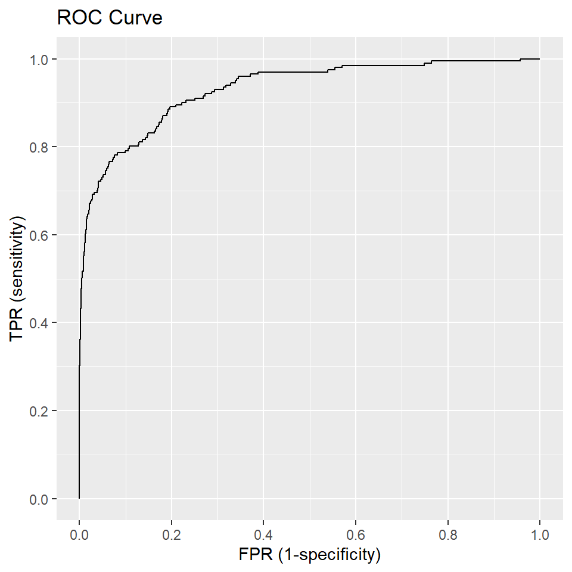

```r
# Set Seed
set.seed(666)

# Create a empty list to store results
output <- list()

# Simulation
for (m in 1:25) {
  # Hold out 500 observations
  holdout <- sample(nrow(train), 500, replace = FALSE)

  # Define train and hold out data
  X.train = train[-holdout,] %>% select(-y) %>% as.matrix()
  Y.train = train[-holdout,] %>% select(y) %>% as.matrix()

  X.valid = train[holdout,] %>% select(-y) %>% as.matrix()
  Y.valid = train[holdout,] %>% select(y)

  # Cross Validation Setting
  n.folds <- 10
  fold <- sample(rep(1:n.folds, length = nrow(X.train)))

  # Run the elastic net model to estimate lambda
  model <- cv.glmnet(x = X.train,
                     y = Y.train,
                     foldid = fold,
                     alpha = 0.75,
                     family = 'binomial')

  # Store the calculation to output
  output[[m]] <- train[holdout,] %>%
    select(y) %>%
    mutate(pred_logit = predict(model, newx = X.valid, type = "response"))
}

# Convert list back to data frame
output_roc <- bind_rows(output) %>%
    group_by(pred_logit) %>%
    summarize(n = n(),
              n.1 = sum(y),
              n.0 = n - sum(y)) %>%
    ungroup() %>%
    arrange(pred_logit) %>%
    mutate(FN = cumsum(n.1),    # false negatives
           TN = cumsum(n.0),    # true negatives
           TP = sum(n.1) - FN,  # true positives
           FP = sum(n.0) - TN,  # false positives
           N  = cumsum(n),      # number of cases predicted to be 1
           TPR = TP / sum(n.1),
           FPR = FP / sum(n.0)) %>%
    #- only keep relevant metrics
    select(-n, -n.1, -n.0, pred_logit) %>%
    mutate(Run = m,
           lambda = model$lambda.1se)

# Create a ROC Curve
ggplot() +
  geom_path(data = output_roc, aes(x = FPR, y = TPR)) +
  scale_color_discrete(name = "Run") +
  labs(x = 'FPR (1-specificity)', y = 'TPR (sensitivity)') +
  geom_segment(x = 0, xend = 1, y = 0, yend = 1, lty = 3, color = 'black') +
  scale_x_continuous(breaks = seq(0, 1, by = .2)) +
  scale_y_continuous(breaks = seq(0, 1, by = .2)) +
  ggtitle("ROC Curve")
```

5. Contest Part 1: Predict the estimated *probability* of linkage for the test data (using any model).
   - Submit a .csv file (ensure comma separated format) named `lastname_firstname_1.csv` that includes the column named **p** that is your estimated posterior probability. We will use automated evaluation, so the format must be exact.
   - You are free to use any tuning parameters
   - You are free to use any data transformation or feature engineering
   - You will receive credit for a proper submission; the top five scores will receive 2 bonus points.
   - Your probabilities will be evaluated with respect to the mean negative Bernoulli log-likelihood (known as the average *log-loss* metric)
     $$L = - \frac{1}{M} \sum_{i=1}^m [y_i \log \, \hat{p}_i + (1 - y_i) \log \, (1 - \hat{p}_i)]$$
     where $M$ is the number of test observations, $\hat{p}_i$ is the prediction for the $i$th test observation, and $y_i \in \{0,1\}$ are the true test set labels.

```r
# Reading in the train and test
train <- read_csv("https://mdporter.github.io/SYS6018/data/linkage_train.csv")

# Log transformation of the TIMERANGE
train$TIMERANGE <- ifelse(train$TIMERANGE == 0, 0, log(train$TIMERANGE))

# Control Randomness
set.seed(666)

# Cross Validation Setting
n.folds <- 10
fold <- sample(rep(1:n.folds, length = nrow(train)))

# Pre-defined setting
alpha <- seq(0, 1, 0.05)

# Create a empty list to store results
output <- list()

# Finding the best alpha
for (m in 1:length(alpha)) {

  # Create an empty fold list to record loss on each fold
  fold_list <- list()

  # Find the average loss cross fold
  for (f in 1:n.folds) {
    # Define train and hold out data
    X.train = train[fold != f,] %>% select(-y) %>% as.matrix()
    Y.train = train[fold != f,] %>% select(y) %>% as.matrix()

    X.valid = train[fold == f,] %>% select(-y) %>% as.matrix()
    Y.valid = train[fold == f,] %>% select(y)

    # Build model using CV
    model <- glmnet(x = X.train,
                    y = Y.train,
                    alpha = alpha[m],
                    family = 'binomial')

    # Create an empty loss list to pick lambda
    loss <- list()

    # Finding the best lambda
    for (i in 1:length(model$lambda)) {
      loss[[i]] <-  Y.valid %>%
        mutate(lambda = model$lambda[i]) %>%
        mutate(pred = predict(model, newx = X.valid,
                              s = model$lambda[i], type = 'response')) %>%
        mutate(loss = (y * log(pred) + (1 - y)*log(1 - pred))) %>%
        group_by(lambda) %>%
        summarise(loss = -mean(loss))
    }

    # Convert loss list back to data frame
    fold_list[[f]] <- bind_rows(loss) %>%
      filter(loss == min(loss)) %>%
      mutate(fold = f)

  }
  # Convert fold list back to data frame
    output[[m]] <- bind_rows(fold_list) %>%
      mutate(alpha = alpha[m]) %>%
      group_by(alpha) %>%
      summarise(lambda = mean(lambda), loss = mean(loss))
    # print(m) # tracking where we are :)
}

# Get final prediction parameters
final <- bind_rows(output) %>%
  filter(loss == min(loss))
final
```

```
#> # A tibble: 1 x 3
#>   alpha   lambda   loss
#>   <dbl>    <dbl>  <dbl>
#> 1  0.05 0.000287 0.0457
```

```r
# Read in test data
test <- read_csv("https://mdporter.github.io/SYS6018/data/linkage_test.csv")

# Refit model with best alpha and best lambda using all training data
model <- glmnet(x = train %>% select(-y) %>% as.matrix(),
                y = train %>% select(y) %>% as.matrix(),
                alpha = final$alpha[1],
                family = 'binomial')

# Convert test from data frame to matrix
Y.test <-  test %>%
  mutate(TIMERANGE = ifelse(TIMERANGE == 0, 0, log(TIMERANGE))) %>%
  as.matrix()

# Make final prediction
test$p <- predict(model, newx = Y.test, s = final$lambda[1], type = 'response')

# Write out the CSV file
write_csv(test, "xu_congxin_1.csv")
```

6. Contest Part 2: Predict the linkages for the test data (using any model).
   - Submit a .csv file (ensure comma separated format) named `lastname_firstname_2.csv` that includes the column named **link** that takes the value of 1 for linkages and 0 for unlinked pairs. We will use automated evaluation, so the format must be exact.
   - You are free to use any tuning parameters.
   - You are free to use any data transformation or feature engineering.
   - Your labels will be evaluated based on total cost, where cost is equal to `1*FP + 8*FN`. This implies that False Negatives (FN) are 8 times as costly as False Negatives (FP)
   - You will receive credit for a proper submission; the top five scores will receive 2 bonus points. Note: you only will get bonus credit for one of the two contests.

In my previous part, I have found the best parameter for alpha and lambda to calculate the probability of linkage for the test data. Now, we just need to find the best threshold that classifies the probability into different classes that minimize the cost function.

```r
# Reading in the train and test
train <- read_csv("https://mdporter.github.io/SYS6018/data/linkage_train.csv")

# Log transformation of the TIMERANGE
train$TIMERANGE <- ifelse(train$TIMERANGE == 0, 0, log(train$TIMERANGE))

# Control Randomness
set.seed(666)

# Cross Validation Setting
n.folds <- 10
fold <- sample(rep(1:n.folds, length = nrow(train)))

# Pre-defined setting
alpha <-  0.05 # final$alpha[1]
lambda <- 0.0002865133 # final$lambda[1]
threshold <- seq(0, 1, 0.001)

# Create a empty list to store results
output <- list()

# Find the average loss cross fold
for (f in 1:n.folds) {
  # Define train and hold out data
  X.train = train[fold != f,] %>% select(-y) %>% as.matrix()
  Y.train = train[fold != f,] %>% select(y) %>% as.matrix()

  X.valid = train[fold == f,] %>% select(-y) %>% as.matrix()
  Y.valid = train[fold == f,] %>% select(y)

  # Build model using CV
  model <- glmnet(x = X.train,
                  y = Y.train,
                  alpha = alpha,
                  family = 'binomial')

  # Create an empty loss list to pick lambda
  loss <- list()

  # Finding the best threshold
  for (i in 1:length(threshold)) {
    loss[[i]] <- Y.valid %>%
      mutate(pred = predict(model, newx = X.valid,
                            s = lambda, type = 'response')) %>%
      mutate(pred = ifelse(pred >= threshold[i], 1, 0),
             FP = ifelse(pred == 1 & y == 0, 1, 0),
             FN = ifelse(pred == 0 & y == 1, 1, 0),
             loss =  1 * FP + 8 * FN,
             threshold = threshold[i]) %>%
      group_by(threshold) %>%
      summarise(loss = sum(loss))
  }

  # Convert loss list back to data frame
  output[[f]] <- bind_rows(loss) %>%
    filter(loss == min(loss)) %>%
    mutate(fold = f)

}

# Get final prediction parameters
final <- bind_rows(output) %>%
  select(threshold, loss, fold) %>%
  group_by(fold) %>%
  summarise(threshold = mean(threshold), loss = mean(loss)) %>%
  mutate(Id = "Final") %>%
  group_by(Id) %>%
  summarise(threshold = mean(threshold), loss = mean(loss)) %>%
  print()
```

```
#> # A tibble: 1 x 3
#>   Id    threshold  loss
#>   <chr>     <dbl> <dbl>
#> 1 Final     0.165  182.
```

```r
# Read in test data
test <- read_csv("https://mdporter.github.io/SYS6018/data/linkage_test.csv")

# Refit model with best alpha and best lambda using all training data
model <- glmnet(x = train %>% select(-y) %>% as.matrix(),
                y = train %>% select(y) %>% as.matrix(),
                alpha = alpha,
                family = 'binomial')

# Convert test from data frame to matrix
Y.test <-  test %>%
  mutate(TIMERANGE = ifelse(TIMERANGE == 0, 0, log(TIMERANGE))) %>%
  as.matrix()

# Make final prediction
test$link <- ifelse(predict(model, newx = Y.test, s = lambda, type = 'response') >= final$threshold[1], 1, 0)

# Write out the CSV file
write_csv(test, "xu_congxin_2.csv")
```